# Assignment1

Author

Xinran Wang

## Settings

```r
suppressPackageStartupMessages(library(knitr))

suppressPackageStartupMessages(library(data.table))
suppressPackageStartupMessages(library(tidyverse))
suppressPackageStartupMessages(library(datasauRus))

suppressPackageStartupMessages(library(skimr))

suppressPackageStartupMessages(library(ggplot2))
suppressPackageStartupMessages(library(ggthemes))
suppressPackageStartupMessages(library(ggpubr))

suppressPackageStartupMessages(library(leaflet))
suppressPackageStartupMessages(library(leaflet.extras2))
```

```r
idir <- "/Users/xinranwang/Documents/Course/25Fall/PM566/Data"
```

## EDA

1. (30 points) Given the formulated question from the assignment description, you will now conduct EDA Checklist items 1-5. First, download 2002 and 2022 data for all sites in California from the [EPA Air Quality Data website](https://www.epa.gov/outdoor-air-quality-data/download-daily-data), then read the data into R. For each of the two datasets, check the dimensions, headers, footers, variable names and variable types. Check the distribution of the key variable we are analyzing (PM). Write up a summary of all of your findings.

   **Note.** Since `skim` collapse all number into `numeric`, I also attached a table to distinguish between numerical types

   **Summary.** This data frame includes measurements at the state level (California), county level (51 counties), and city level (199 monitoring sites). PM2.5 was recorded using 21 different methods (see `Method.Description` column for details) and reported in units of µg/m3 LC. Other parameters such as daily AQI level, AQS code and description, CBSA code and name, etc. are also available.

   There is a striking decrease in daily PM2.5 concentrations from 2002 to 2022. Mean and median PM 2.5 were cut in half. However, there are more outliers in 2022 and max PM 2.5 increased by 3 fold.

   ```r
   read_df <- function(idir, filename, year){
     df <- read.csv(paste0(idir, "/", filename)) %>% mutate(Year = year)
     return(df)
   }
   ```

   ```r
   check_df <- function(df){
     print(paste0("Dimension: ", paste(dim(df), collapse = " x "),
                  "; # Rows: ", nrow(df),
                  "; # Columns: ", ncol(df)))

     df_type <- data.frame(Type = sapply(df, function(x) paste(class(x), collapse = ", ")))
     kable(df_type, caption = "Variable types in df")
   }
   ```

## 2002

   ```r
   df_2002 <- read_df(idir, "ad_viz_plotval_data_PM2.5_2002.csv", "2002")
   check_df(df_2002)
   ```

   ```
   [1] "Dimension: 15976 x 23; # Rows: 15976; # Columns: 23"
   ```

   Variable types in df

   |  | Type |
   | --- | --- |
   | Date | character |
   | Source | character |
   | Site.ID | integer |
   | POC | integer |
   | Daily.Mean.PM2.5.Concentration | numeric |
   | Units | character |
   | Daily.AQI.Value | integer |
   | Local.Site.Name | character |
   | Daily.Obs.Count | integer |
   | Percent.Complete | numeric |
   | AQS.Parameter.Code | integer |
   | AQS.Parameter.Description | character |
   | Method.Code | integer |
   | Method.Description | character |
   | CBSA.Code | integer |
   | CBSA.Name | character |
   | State.FIPS.Code | integer |
   | State | character |
   | County.FIPS.Code | integer |
   | County | character |
   | Site.Latitude | numeric |
   | Site.Longitude | numeric |
   | Year | character |

   ```r
   skim(df_2002)
   ```

   Data summary

   | Name | df_2002 |
   | --- | --- |
   | Number of rows | 15976 |
   | Number of columns | 23 |
   | _______________________ |  |
   | Column type frequency: |  |
   | character | 10 |
   | numeric | 13 |
   | ________________________ |  |
   | Group variables | None |

   **Variable type: character**

   | skim_variable | n_missing | complete_rate | min | max | empty | n_unique | whitespace |
   | --- | --- | --- | --- | --- | --- | --- | --- |
   | Date | 0 | 1 | 10 | 10 | 0 | 365 | 0 |
   | Source | 0 | 1 | 3 | 3 | 0 | 1 | 0 |
   | Units | 0 | 1 | 8 | 8 | 0 | 1 | 0 |
   | Local.Site.Name | 0 | 1 | 0 | 43 | 118 | 103 | 0 |
   | AQS.Parameter.Description | 0 | 1 | 24 | 38 | 0 | 2 | 0 |
   | Method.Description | 0 | 1 | 28 | 62 | 0 | 6 | 0 |
   | CBSA.Name | 0 | 1 | 0 | 45 | 929 | 31 | 0 |
   | State | 0 | 1 | 10 | 10 | 0 | 1 | 0 |
   | County | 0 | 1 | 4 | 15 | 0 | 48 | 0 |
   | Year | 0 | 1 | 4 | 4 | 0 | 1 | 0 |

   **Variable type: numeric**

   | skim_variable | n_missing | complete_rate | mean | sd | p0 | p25 | p50 | p75 | p100 | hist |
   | --- | --- | --- | --- | --- | --- | --- | --- | --- | --- | --- |
   | Site.ID | 0 | 1.00 | 60549600.12 | 289945.67 | 60010007.00 | 60290014.00 | 60590007.00 | 60731002.00 | 61131003.00 | ▃▇▅▆▃ |
   | POC | 0 | 1.00 | 1.58 | 1.25 | 1.00 | 1.00 | 1.00 | 1.00 | 6.00 | ▇▁▁▁▁ |
   | Daily.Mean.PM2.5.Concentration | 0 | 1.00 | 16.12 | 13.87 | 0.00 | 7.00 | 12.00 | 20.50 | 104.30 | ▇▂▁▁▁ |
   | Daily.AQI.Value | 0 | 1.00 | 59.28 | 31.95 | 0.00 | 39.00 | 56.00 | 72.00 | 185.00 | ▃▇▂▁▁ |
   | Daily.Obs.Count | 0 | 1.00 | 1.00 | 0.00 | 1.00 | 1.00 | 1.00 | 1.00 | 1.00 | ▁▁▇▁▁ |
   | Percent.Complete | 0 | 1.00 | 100.00 | 0.00 | 100.00 | 100.00 | 100.00 | 100.00 | 100.00 | ▁▁▇▁▁ |
   | AQS.Parameter.Code | 0 | 1.00 | 88215.26 | 181.01 | 88101.00 | 88101.00 | 88101.00 | 88502.00 | 88502.00 | ▇▁▁▁▃ |
   | Method.Code | 0 | 1.00 | 297.04 | 282.45 | 117.00 | 120.00 | 120.00 | 707.00 | 810.00 | ▇▁▁▁▃ |
   | CBSA.Code | 929 | 0.94 | 33269.99 | 11059.59 | 12540.00 | 23420.00 | 40140.00 | 41740.00 | 49700.00 | ▃▂▃▇▁ |
   | State.FIPS.Code | 0 | 1.00 | 6.00 | 0.00 | 6.00 | 6.00 | 6.00 | 6.00 | 6.00 | ▁▁▇▁▁ |
   | County.FIPS.Code | 0 | 1.00 | 54.78 | 28.98 | 1.00 | 29.00 | 59.00 | 73.00 | 113.00 | ▃▇▅▆▃ |
   | Site.Latitude | 0 | 1.00 | 36.00 | 2.28 | 32.63 | 34.07 | 35.36 | 37.77 | 41.71 | ▇▃▅▃▁ |
   | Site.Longitude | 0 | 1.00 | -119.38 | 1.95 | -124.16 | -121.37 | -119.06 | -117.87 | -115.48 | ▁▇▇▇▅ |

   ```r
   kable(head(df_2002, 1), caption = "Head of df")
   ```

   Head of df

   | Date | Source | Site.ID | POC | Daily.Mean.PM2.5.Concentration | Units | Daily.AQI.Value | Local.Site.Name | Daily.Obs.Count | Percent.Complete | AQS.Parameter.Code | AQS.Parameter.Description | Method.Code | Method.Description | CBSA.Code | CBSA.Name | State.FIPS.Code | State | County.FIPS.Code | County | Site.Latitude | Site.Longitude | Year |
   | --- | --- | --- | --- | --- | --- | --- | --- | --- | --- | --- | --- | --- | --- | --- | --- | --- | --- | --- | --- | --- | --- | --- |
   | 01/05/2002 | AQS | 60010007 | 1 | 25.1 | ug/m3 LC | 81 | Livermore | 1 | 100 | 88101 | PM2.5 - Local Conditions | 120 | Andersen RAAS2.5-300 PM2.5 SEQ w/WINS | 41860 | San Francisco-Oakland-Hayward, CA | 6 | California | 1 | Alameda | 37.68753 | -121.7842 | 2002 |

   ```r
   kable(tail(df_2002, 1), caption = "Tail of df")
   ```

   Tail of df

   |  | Date | Source | Site.ID | POC | Daily.Mean.PM2.5.Concentration | Units | Daily.AQI.Value | Local.Site.Name | Daily.Obs.Count | Percent.Complete | AQS.Parameter.Code | AQS.Parameter.Description | Method.Code | Method.Description | CBSA.Code | CBSA.Name | State.FIPS.Code | State | County.FIPS.Code | County | Site.Latitude | Site.Longitude | Year |
   | --- | --- | --- | --- | --- | --- | --- | --- | --- | --- | --- | --- | --- | --- | --- | --- | --- | --- | --- | --- | --- | --- | --- | --- |
   | 15976 | 12/31/2002 | AQS | 61131003 | 1 | 6 | ug/m3 LC | 33 | Woodland-Gibson Road | 1 | 100 | 88101 | PM2.5 - Local Conditions | 117 | R & P Model 2000 PM2.5 Sampler w/WINS | 40900 | Sacramento–Roseville–Arden-Arcade, CA | 6 | California | 113 | Yolo | 38.66121 | -121.7327 | 2002 |

## 2022

   ```r
   df_2022 <- read_df(idir, "ad_viz_plotval_data_PM2.5_2022.csv", "2022")
   check_df(df_2022)
   ```

   ```
   [1] "Dimension: 59918 x 23; # Rows: 59918; # Columns: 23"
   ```

   Variable types in df

   |  | Type |
   | --- | --- |
   | Date | character |
   | Source | character |
   | Site.ID | integer |
   | POC | integer |
   | Daily.Mean.PM2.5.Concentration | numeric |
   | Units | character |
   | Daily.AQI.Value | integer |
   | Local.Site.Name | character |
   | Daily.Obs.Count | integer |
   | Percent.Complete | numeric |
   | AQS.Parameter.Code | integer |
   | AQS.Parameter.Description | character |
   | Method.Code | integer |
   | Method.Description | character |
   | CBSA.Code | integer |
   | CBSA.Name | character |
   | State.FIPS.Code | integer |
   | State | character |
   | County.FIPS.Code | integer |
   | County | character |
   | Site.Latitude | numeric |
   | Site.Longitude | numeric |
   | Year | character |

   ```r
   skim(df_2022)
   ```

   Data summary

   | Name | df_2022 |
   | --- | --- |
   | Number of rows | 59918 |
   | Number of columns | 23 |
   | _______________________ |  |
   | Column type frequency: |  |
   | character | 10 |
   | numeric | 13 |
   | ________________________ |  |
   | Group variables | None |

   **Variable type: character**

   | skim_variable | n_missing | complete_rate | min | max | empty | n_unique | whitespace |
   | --- | --- | --- | --- | --- | --- | --- | --- |
   | Date | 0 | 1 | 10 | 10 | 0 | 365 | 0 |
   | Source | 0 | 1 | 3 | 3 | 0 | 1 | 0 |
   | Units | 0 | 1 | 8 | 8 | 0 | 1 | 0 |
   | Local.Site.Name | 0 | 1 | 3 | 42 | 0 | 165 | 0 |
   | AQS.Parameter.Description | 0 | 1 | 24 | 38 | 0 | 2 | 0 |
   | Method.Description | 0 | 1 | 24 | 62 | 0 | 18 | 0 |
   | CBSA.Name | 0 | 1 | 0 | 45 | 4569 | 33 | 0 |
   | State | 0 | 1 | 10 | 10 | 0 | 1 | 0 |
   | County | 0 | 1 | 4 | 15 | 0 | 50 | 0 |
   | Year | 0 | 1 | 4 | 4 | 0 | 1 | 0 |

   **Variable type: numeric**

   | skim_variable | n_missing | complete_rate | mean | sd | p0 | p25 | p50 | p75 | p100 | hist |
   | --- | --- | --- | --- | --- | --- | --- | --- | --- | --- | --- |
   | Site.ID | 0 | 1.00 | 60564224.91 | 290630.89 | 60010007.00 | 60290019.00 | 60631006.00 | 60731026.00 | 61131003.00 | ▅▇▇▇▃ |
   | POC | 0 | 1.00 | 3.77 | 4.87 | 1.00 | 1.00 | 3.00 | 3.00 | 24.00 | ▇▁▁▁▁ |
   | Daily.Mean.PM2.5.Concentration | 0 | 1.00 | 8.41 | 7.64 | -6.70 | 4.10 | 6.80 | 10.70 | 302.50 | ▇▁▁▁▁ |
   | Daily.AQI.Value | 0 | 1.00 | 39.22 | 21.55 | 0.00 | 23.00 | 38.00 | 54.00 | 454.00 | ▇▁▁▁▁ |
   | Daily.Obs.Count | 0 | 1.00 | 1.00 | 0.00 | 1.00 | 1.00 | 1.00 | 1.00 | 1.00 | ▁▁▇▁▁ |
   | Percent.Complete | 0 | 1.00 | 100.00 | 0.00 | 100.00 | 100.00 | 100.00 | 100.00 | 100.00 | ▁▁▇▁▁ |
   | AQS.Parameter.Code | 0 | 1.00 | 88192.43 | 168.24 | 88101.00 | 88101.00 | 88101.00 | 88101.00 | 88502.00 | ▇▁▁▁▂ |
   | Method.Code | 0 | 1.00 | 337.99 | 253.07 | 143.00 | 170.00 | 170.00 | 707.00 | 810.00 | ▇▁▁▁▃ |
   | CBSA.Code | 4569 | 0.92 | 34970.64 | 10229.06 | 12540.00 | 31080.00 | 40140.00 | 41860.00 | 49700.00 | ▂▂▂▇▂ |
   | State.FIPS.Code | 0 | 1.00 | 6.00 | 0.00 | 6.00 | 6.00 | 6.00 | 6.00 | 6.00 | ▁▁▇▁▁ |
   | County.FIPS.Code | 0 | 1.00 | 56.28 | 29.06 | 1.00 | 29.00 | 63.00 | 73.00 | 113.00 | ▅▇▇▇▃ |
   | Site.Latitude | 0 | 1.00 | 36.25 | 2.31 | 32.58 | 34.07 | 36.49 | 37.96 | 41.76 | ▇▃▇▅▁ |
   | Site.Longitude | 0 | 1.00 | -119.57 | 2.04 | -124.20 | -121.37 | -119.59 | -117.94 | -115.48 | ▁▇▆▇▃ |

   ```r
   kable(head(df_2022, 1), caption = "Head of df")
   ```

   Head of df

   | Date | Source | Site.ID | POC | Daily.Mean.PM2.5.Concentration | Units | Daily.AQI.Value | Local.Site.Name | Daily.Obs.Count | Percent.Complete | AQS.Parameter.Code | AQS.Parameter.Description | Method.Code | Method.Description | CBSA.Code | CBSA.Name | State.FIPS.Code | State | County.FIPS.Code | County | Site.Latitude | Site.Longitude | Year |
   | --- | --- | --- | --- | --- | --- | --- | --- | --- | --- | --- | --- | --- | --- | --- | --- | --- | --- | --- | --- | --- | --- | --- |
   | 01/01/2022 | AQS | 60010007 | 3 | 12.7 | ug/m3 LC | 58 | Livermore | 1 | 100 | 88101 | PM2.5 - Local Conditions | 170 | Met One BAM-1020 Mass Monitor w/VSCC | 41860 | San Francisco-Oakland-Hayward, CA | 6 | California | 1 | Alameda | 37.68753 | -121.7842 | 2022 |

   ```r
   kable(tail(df_2022, 1), caption = "Tail of df")
   ```

   Tail of df

   |  | Date | Source | Site.ID | POC | Daily.Mean.PM2.5.Concentration | Units | Daily.AQI.Value | Local.Site.Name | Daily.Obs.Count | Percent.Complete | AQS.Parameter.Code | AQS.Parameter.Description | Method.Code | Method.Description | CBSA.Code | CBSA.Name | State.FIPS.Code | State | County.FIPS.Code | County | Site.Latitude | Site.Longitude | Year |
   | --- | --- | --- | --- | --- | --- | --- | --- | --- | --- | --- | --- | --- | --- | --- | --- | --- | --- | --- | --- | --- | --- | --- | --- |
   | 59918 | 12/31/2022 | AQS | 61131003 | 1 | 1 | ug/m3 LC | 6 | Woodland-Gibson Road | 1 | 100 | 88101 | PM2.5 - Local Conditions | 145 | R & P Model 2025 PM-2.5 Sequential Air Sampler w/VSCC | 40900 | Sacramento–Roseville–Arden-Arcade, CA | 6 | California | 113 | Yolo | 38.66121 | -121.7327 | 2022 |

   ```r
   identical(colnames(df_2002), colnames(df_2022))
   ```

   ```
   [1] TRUE
   ```

   **Note.** Here, I combined data frames as they have identical column names.

   ```r
   df <- rbind(df_2002, df_2022)
   rm(df_2002, df_2022)
   ```

## Distribution of PM 2.5

   ```r
   df <- df %>% rename(PM2.5 = Daily.Mean.PM2.5.Concentration)
   df$Year <- factor(df$Year, levels = c("2002", "2022"))

   summary_pm2.5 <- df %>%
     group_by(Year) %>%
     summarise(
       mean          = round(mean(PM2.5, na.rm = T), 2),
       sd            = round(sd(PM2.5, na.rm = TRUE), 2),
       min           = min(PM2.5, na.rm = TRUE),
       q25           = quantile(PM2.5, 0.25, na.rm = TRUE),
       median        = median(PM2.5, na.rm = TRUE),
       q75           = quantile(PM2.5, 0.75, na.rm = TRUE),
       max           = max(PM2.5, na.rm = TRUE)
     )
   kable(as.data.frame(summary_pm2.5), align = "c")
   ```

   | Year | mean | sd | min | q25 | median | q75 | max |
   | --- | --- | --- | --- | --- | --- | --- | --- |
   | 2002 | 16.12 | 13.87 | 0.0 | 7.0 | 12.0 | 20.5 | 104.3 |
   | 2022 | 8.41 | 7.64 | -6.7 | 4.1 | 6.8 | 10.7 | 302.5 |

2. (10 points) Combine the two years of data into one data frame. Use the `Date` variable to create a new column for year, which will serve as an identifier. Change the names of the key variables so that they are easier to refer to in your code.

   **Note.** (1) I’ve created new column for year when reading data, (2) I’ve renamed Daily.Mean.PM2.5.Concentration to PM2.5 in previous step (3) I’ve combined data in previous step.
3. (20 points) Create a basic map (or maps) in `leaflet` showing the locations of the monitoring sites, using different colors for each year. Summarize the spatial distribution of the sites. How does this distribution change from 2002 to 2022?

## Map (2002 vs 2022)

   https://rdrr.io/cran/leaflet.extras2/man/addSidebyside.html

   ```r
   # Map
   #scales::hue_pal()(2)
   pal <- leaflet::colorFactor(c("#F8766D", "#00BFC4"), domain = levels(df$Year))

   leaflet(df) %>%
     addMapPane("left",  zIndex = 410) %>%
     addMapPane("right", zIndex = 410) %>%

     addProviderTiles('OpenStreetMap',
                  options = pathOptions(pane = "left"),
                  layerId = "layer_2002") %>%
     addProviderTiles('OpenStreetMap',
                  options = pathOptions(pane = "right"),
                  layerId = "layer_2022") %>%

     addCircles(data = df %>% filter(Year == 2002),
                lat = ~Site.Latitude,
                lng = ~Site.Longitude,
                fillColor = "#F8766D",
                color = "black",
                stroke = TRUE,
                weight = 0.2,
                opacity = 0.5,
                fillOpacity = 1,
                radius = 100,
                options = pathOptions(pane = "left"),
                group = "2002") %>%

     addCircles(data = df %>% filter(Year == 2022),
                lat = ~Site.Latitude,
                lng = ~Site.Longitude,
                fillColor = "#00BFC4",
                color = "black",
                stroke = TRUE,
                weight = 0.2,
                opacity = 0.5,
                fillOpacity = 1,
                radius = 100,
                options = pathOptions(pane = "right"),
                group = "2022") %>%

     addLegend("topright",
               title = "Location of Monitor Sites",
               pal = pal, values = ~Year, labels = ~Year
               ) %>%

     addLayersControl(overlayGroups = ~c("2002", "2022"),
                  options = layersControlOptions(collapsed = F)) %>%

     addSidebyside(
         layerId = "sidecontrols",
         leftId = "layer_2002",
         rightId = "layer_2022")
   ```

[interactive chart not shown]

4. (10 points) Check for any data issues such as missing or implausible values of PM in the combined dataset. Calculate the proportion of missing/implausible values for each year and report any temporal patterns you see in these observations.

   **Missing values.** There are no missing values in either year.

   **Implausible values.** In 2022, 215 out of 59,918 observations (0.36%) were implausible (defined as PM2.5 < 0).

   **Temporal Patterns.** The number of implausible observations increased in 2022, although the count remained very small overall.

   ```r
   summary_missingness <- df %>%
     group_by(Year) %>%
     summarise(
       `# Total`          = n(),
       `# Missing`        = sum(is.na(PM2.5)),
       `# Implausible`    = sum(PM2.5 < 0, na.rm = TRUE)
     ) %>%
     mutate(
       `% Missing`     = paste0(round((`# Missing` / `# Total`) * 100, 2), "%"),
       `% Implausible` = paste0(round((`# Implausible` / `# Total`) * 100, 2), "%")) %>%
     select(`# Total`, `# Missing`, `% Missing`, `# Implausible`, `% Implausible`)

   kable(as.data.frame(summary_missingness), align = "c")
   ```

   | # Total | # Missing | % Missing | # Implausible | % Implausible |
   | --- | --- | --- | --- | --- |
   | 15976 | 0 | 0% | 0 | 0% |
   | 59918 | 0 | 0% | 215 | 0.36% |

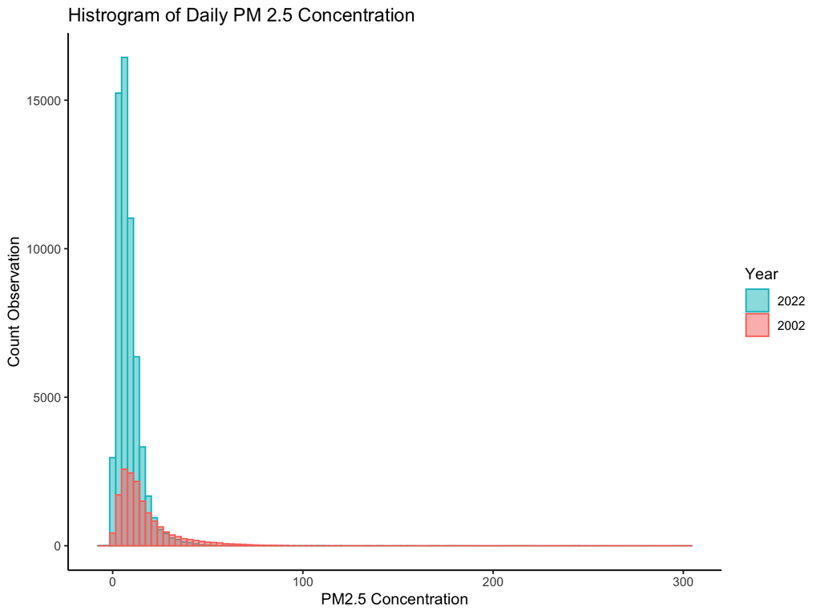

   ```r
   # Count of PM 2.5 Concentration
   df$Year <- factor(df$Year, levels = c("2022", "2002"))  # 2002 will be drawn last (on top)
   ggplot(df, aes(x = PM2.5, fill = Year, color = Year)) +
     geom_histogram(bins = 100, alpha = 0.5, position = "identity") +
     labs(title = "Histrogram of Daily PM 2.5 Concentration",
          x = "PM2.5 Concentration",
          y = "Count Observation") +
     scale_color_manual(name = "Year",
                        values = c("2002" = "#F8766D", "2022" = "#00BFC4")) +
     scale_fill_manual(name = "Year",
                        values = c("2002" = "#F8766D", "2022" = "#00BFC4")) +
     theme_classic()
   ```

   ```r
   df$Year <- factor(df$Year, levels = c("2002", "2022"))  # 2002 will be drawn last (on top)
   ```

5. (30 points) Explore the main question of interest at three different levels of spatial resolution. Create exploratory plots (e.g. boxplots, histograms, line plots, violin plots) and summary statistics that best suit each level of data. Be sure to write up explanations of what you observe in these data.
- Level 1: State. Examine the primary question for the entire state.
- Level 2: County. Examine the primary question for every county in California.
- Level 3: City. Restrict the data to sites in Los Angeles county and examine the primary question for every site.

## Level 1: State

  **Summary.** The mean of daily PM 2.5 in 2022 (mean: 8.41; sd: 7.64) is lower than than 2002 (mean: 16.12; sd: 13.87), suggesting long term improvements in air quality. The increase in amount and magnitude of outliers likely reflect wildfire in 2022.

  ```r
  summary_byState <- df %>%
    group_by(Year) %>%
    summarise(
      n             = n(),
      mean          = round(mean(PM2.5, na.rm = T), 2),
      sd            = round(sd(PM2.5, na.rm = T), 2)) %>%
    mutate(`Mean (SD)`= paste0(mean, " (", sd, ")")) %>%
    select(Year, `Mean (SD)`) %>%
    arrange(Year)
  kable(as.data.frame(summary_byState), align = "c")
  ```

  | Year | Mean (SD) |
  | --- | --- |
  | 2002 | 16.12 (13.87) |
  | 2022 | 8.41 (7.64) |

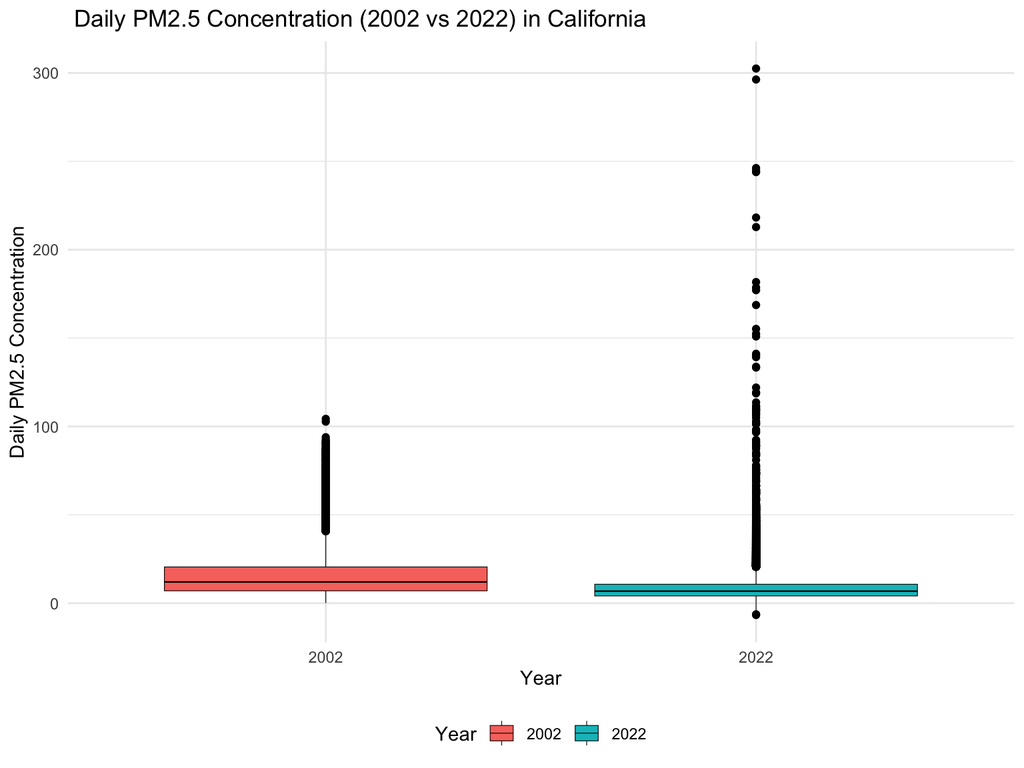

  ```r
  ggplot(df, aes_string(x = "Year", y = "PM2.5", fill = "Year", color = "Year")) +
    geom_boxplot(color = "black", size = 0.2) +
    labs(title = paste0(" Daily PM2.5 Concentration (2002 vs 2022) in California"),
         x = "Year",
         y = paste0("Daily PM2.5 Concentration")) +
    scale_color_manual(name = "Year",
                       values = c("2002" = "#F8766D", "2022" = "#00BFC4")) +
    theme_minimal() +
    theme(legend.position = "bottom",
          legend.box = "horizontal",
          legend.justification = "center")
  ```

## Level 2: County

  **Summary.** Counties in California show decreasing trends in PM 2.5 between 2002 and 2022. The reductions are particularly notable in Riverside, Butte, Kern,San Francisco, Tulare, Merced, and San Joaquin, where PM 2.5 dropped by more than 50%.

  ```r
  summary_byCounty <- df %>%
    group_by(County, Year) %>%
    summarise(
      n             = n(),
      mean          = round(mean(PM2.5, na.rm = T), 2),
      sd            = round(sd(PM2.5, na.rm = TRUE), 2)) %>%
    mutate(`Mean (SD)`= paste0(mean, " (", sd, ")")) %>%
    select(Year, County, `Mean (SD)`) %>%
    pivot_wider(
      names_from = Year,
      values_from = `Mean (SD)`,
      names_prefix = "Mean (SD) in ") %>%
    mutate(mean_2002 = as.numeric(str_extract(`Mean (SD) in 2002`, "^[0-9.]+")),
           mean_2022 = as.numeric(str_extract(`Mean (SD) in 2022`, "^[0-9.]+")),
           `Difference in Mean (2022 - 2002)` = (mean_2022 - mean_2002),
           `% Change in Mean (2022 - 2002)` = round(((mean_2022 - mean_2002)/mean_2002)*100, 2)) %>%
    arrange(`% Change in Mean (2022 - 2002)`) %>%
    mutate(`Difference (% Change)` = paste0(`Difference in Mean (2022 - 2002)`, " (", `% Change in Mean (2022 - 2002)`, "%)")) %>%
    select(County, `Mean (SD) in 2002`, `Mean (SD) in 2022`, `Difference (% Change)`)
  kable(as.data.frame(summary_byCounty), align = "c")
  ```

  | County | Mean (SD) in 2002 | Mean (SD) in 2022 | Difference (% Change) |
  | --- | --- | --- | --- |
  | Riverside | 22.37 (16.1) | 9.13 (6.27) | -13.24 (-59.19%) |
  | Butte | 14.76 (11.66) | 6.19 (5.79) | -8.57 (-58.06%) |
  | Kern | 23 (18.72) | 9.88 (9.91) | -13.12 (-57.04%) |
  | San Francisco | 15.31 (14.21) | 6.78 (5.14) | -8.53 (-55.72%) |
  | Tulare | 23.1 (16.15) | 10.41 (7.53) | -12.69 (-54.94%) |
  | Merced | 21.54 (15.32) | 10.06 (7.32) | -11.48 (-53.3%) |
  | San Joaquin | 16.76 (12.26) | 7.9 (7.81) | -8.86 (-52.86%) |
  | Solano | 15.48 (14.15) | 7.9 (5.46) | -7.58 (-48.97%) |
  | Ventura | 13.4 (7.24) | 6.85 (3.83) | -6.55 (-48.88%) |
  | Fresno | 19.93 (18.91) | 10.19 (8.3) | -9.74 (-48.87%) |
  | Yolo | 10.58 (8.86) | 5.44 (5.29) | -5.14 (-48.58%) |
  | Orange | 17.83 (10.55) | 9.24 (4.43) | -8.59 (-48.18%) |
  | Monterey | 8.97 (4.53) | 4.75 (3.21) | -4.22 (-47.05%) |
  | San Diego | 15.27 (7.65) | 8.3 (4.36) | -6.97 (-45.65%) |
  | Sacramento | 15.17 (14.51) | 8.25 (7.54) | -6.92 (-45.62%) |
  | Contra Costa | 15.09 (14.47) | 8.24 (4.93) | -6.85 (-45.39%) |
  | San Mateo | 12.24 (8.91) | 6.8 (4.94) | -5.44 (-44.44%) |
  | Placer | 13.1 (10.24) | 7.28 (15.48) | -5.82 (-44.43%) |
  | Los Angeles | 19.66 (11.88) | 10.97 (5.24) | -8.69 (-44.2%) |
  | Sonoma | 11.13 (9.5) | 6.38 (4.29) | -4.75 (-42.68%) |
  | Alameda | 14.25 (11.43) | 8.2 (4.95) | -6.05 (-42.46%) |
  | San Bernardino | 16.3 (13.08) | 9.42 (5.19) | -6.88 (-42.21%) |
  | Kings | 24.7 (19.06) | 14.4 (10.78) | -10.3 (-41.7%) |
  | Santa Clara | 14.83 (10.65) | 8.77 (5.59) | -6.06 (-40.86%) |
  | Calaveras | 9.9 (6.5) | 6.04 (4.1) | -3.86 (-38.99%) |
  | Santa Cruz | 8.55 (4.34) | 5.23 (3.74) | -3.32 (-38.83%) |
  | Stanislaus | 19.66 (17.09) | 12.12 (8.42) | -7.54 (-38.35%) |
  | Colusa | 11.73 (10.01) | 7.61 (4.76) | -4.12 (-35.12%) |
  | Lake | 6.5 (10.88) | 4.26 (3.12) | -2.24 (-34.46%) |
  | Shasta | 7.25 (8.38) | 5.04 (4.67) | -2.21 (-30.48%) |
  | Imperial | 12.71 (7.7) | 9.55 (6.39) | -3.16 (-24.86%) |
  | Inyo | 7.14 (10.49) | 5.55 (5.47) | -1.59 (-22.27%) |
  | Sutter | 12.82 (10.2) | 10.04 (6.6) | -2.78 (-21.68%) |
  | San Luis Obispo | 8.88 (5.15) | 7.1 (4.52) | -1.78 (-20.05%) |
  | El Dorado | 4.91 (4.07) | 4.07 (9.18) | -0.84 (-17.11%) |
  | Santa Barbara | 7.04 (3.92) | 6.06 (3.51) | -0.98 (-13.92%) |
  | Humboldt | 7.79 (4.59) | 6.76 (4.35) | -1.03 (-13.22%) |
  | Plumas | 12.86 (8.94) | 11.23 (10.33) | -1.63 (-12.67%) |
  | Marin | 7.31 (4.87) | 6.54 (4.17) | -0.77 (-10.53%) |
  | San Benito | 4.99 (2.92) | 4.71 (2.69) | -0.28 (-5.61%) |
  | Mariposa | 9.48 (5.97) | 9.47 (17.78) | -0.00999999999999979 (-0.11%) |
  | Nevada | 7.36 (3.41) | 7.59 (15.86) | 0.23 (3.12%) |
  | Mendocino | 8.85 (8.79) | 10.14 (5.19) | 1.29 (14.58%) |
  | Del Norte | 3.82 (2.56) | 4.97 (3.58) | 1.15 (30.1%) |
  | Mono | 2.68 (2.57) | 4.43 (6.09) | 1.75 (65.3%) |
  | Siskiyou | 2.69 (2.06) | 7.6 (17.3) | 4.91 (182.53%) |
  | Trinity | 2.78 (2.4) | 10.73 (23.1) | 7.95 (285.97%) |
  | Glenn | NA | 5.34 (4.98) | NA (NA%) |
  | Madera | NA | 10.39 (7.26) | NA (NA%) |
  | Modoc | 5 (0) | NA | NA (NA%) |
  | Tehama | NA | 5.87 (4.5) | NA (NA%) |

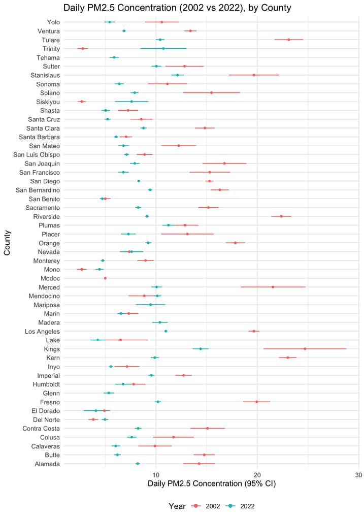

  ```r
  df_couty <- df %>% group_by(Year, County) %>%
    summarise(
      n             = n(),
      mean_PM2.5    = mean(PM2.5, na.rm = T),
      sd_PM2.5      = sd(PM2.5, na.rm = T),
    ) %>%
    mutate(se_PM2.5 = sd_PM2.5 / sqrt(n))
  ggplot(df_couty,
         aes(y = County, x = mean_PM2.5,
             xmin = mean_PM2.5 - 1.96 * se_PM2.5,
             xmax = mean_PM2.5 + 1.96 * se_PM2.5,
             color = Year, group = Year)) +
    geom_pointrange(size = 0.3, fatten = 1.2) +
    labs(title = paste0("Daily PM2.5 Concentration (2002 vs 2022), by County"),
         x = "Daily PM2.5 Concentration (95% CI)", y = "County",) +
    scale_color_manual(name = "Year",
                       values = c("2002" = "#F8766D", "2022" = "#00BFC4")) +
    theme_minimal() +
    theme(legend.position = "bottom",
          legend.box = "horizontal",
          legend.justification = "center")
  ```

## Level 3: Sites in LA County

  **Summary.** The sites in LA county shows a clear decline in daily PM 2.5 levels between 2002 and 2022. All sites (that existed in both 2002 and 2022) showed at least 27.39% reduction in PM 2.5 levels. The reduction is particularly notable in Pasadena and Azusa, where mean daily PM 2.5 dropped more than 50%.

  The violin plot showed that the distribution of PM 2.5 in 2022 is generally wider at lower PM 2.5 levels than 2002, indicating a decreasing trend.

  ```r
    summary_bySite <- df %>%
             filter(County == "Los Angeles",
                    Year %in% c("2002", "2022"),
                    Local.Site.Name != "") %>%
        group_by(Year, Local.Site.Name) %>%
        summarise(
          n             = n(),
          mean          = round(mean(PM2.5, na.rm = T), 2),
          sd            = round(sd(PM2.5, na.rm = TRUE), 2)) %>%
        mutate(`Mean (SD)`= paste0(mean, " (", sd, ")")) %>%
        select(Year, Local.Site.Name, `Mean (SD)`) %>%
        pivot_wider(
          names_from = Year,
          values_from = `Mean (SD)`,
          names_prefix = "Mean (SD) in ") %>%
        mutate(`Local Site Name` = Local.Site.Name) %>%
        mutate(mean_2002 = as.numeric(str_extract(`Mean (SD) in 2002`, "^[0-9.]+")),
               mean_2022 = as.numeric(str_extract(`Mean (SD) in 2022`, "^[0-9.]+")),
              `Difference in Mean (2022 - 2002)` = (mean_2022 - mean_2002),
              `% Change in Mean (2022 - 2002)` = round(((mean_2022 - mean_2002)/mean_2002)*100, 2)) %>%
      arrange(`% Change in Mean (2022 - 2002)`) %>%
      mutate(`Difference (% Change)` = paste0(`Difference in Mean (2022 - 2002)`, " (", `% Change in Mean (2022 - 2002)`, "%)")) %>%
      select(Local.Site.Name, `Mean (SD) in 2002`, `Mean (SD) in 2022`, `Difference (% Change)`)
    kable(as.data.frame(summary_bySite), align = "c")
  ```

  | Local.Site.Name | Mean (SD) in 2002 | Mean (SD) in 2022 | Difference (% Change) |
  | --- | --- | --- | --- |
  | Pasadena | 20.29 (11.14) | 9.09 (3.68) | -11.2 (-55.2%) |
  | Azusa | 20.76 (12.11) | 9.72 (4.39) | -11.04 (-53.18%) |
  | Long Beach (North) | 19.47 (10.39) | 9.92 (3.27) | -9.55 (-49.05%) |
  | Los Angeles-North Main Street | 21.97 (11.69) | 11.58 (4.57) | -10.39 (-47.29%) |
  | Reseda | 18.85 (10.65) | 10.72 (4.56) | -8.13 (-43.13%) |
  | Lancaster-Division Street | 10.38 (4.47) | 7.52 (2.48) | -2.86 (-27.55%) |
  | Lebec | 4.82 (2.78) | 3.5 (1.65) | -1.32 (-27.39%) |
  | Burbank | 23.97 (12.74) | NA | NA (NA%) |
  | Lynwood | 23.35 (11.96) | NA | NA (NA%) |
  | Compton | NA | 12.99 (6.22) | NA (NA%) |
  | Glendora | NA | 8.42 (5.47) | NA (NA%) |
  | Long Beach (South) | NA | 11.97 (4.32) | NA (NA%) |
  | Long Beach-Route 710 Near Road | NA | 13.02 (5.61) | NA (NA%) |
  | North Hollywood (NOHO) | NA | 13.02 (4.75) | NA (NA%) |
  | Pico Rivera #2 | NA | 11.45 (5.93) | NA (NA%) |
  | Santa Clarita | NA | 9.14 (3.9) | NA (NA%) |
  | Signal Hill (LBSH) | NA | 8.85 (4.42) | NA (NA%) |

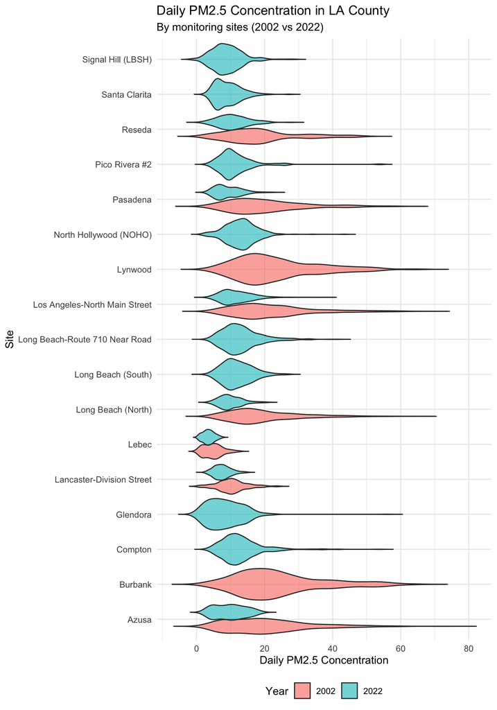

  ```r
    ggplot(df %>%
             filter(County == "Los Angeles",
                    Year %in% c("2002", "2022"),
                    Local.Site.Name != ""),
         aes(x = PM2.5,
             y = Local.Site.Name,
             fill = Year)) +
    geom_violin(alpha = 0.6, scale = "width",
                position = position_dodge(width = 0.8), trim = FALSE) +
    labs(
      title = "Daily PM2.5 Concentration in LA County",
      subtitle = "By monitoring sites (2002 vs 2022)",
      x = "Daily PM2.5 Concentration",
      y = "Site",
      fill = "Year") +
    scale_color_manual(name = "Year",
                           values = c("2002" = "#F8766D", "2022" = "#00BFC4")) +
    scale_fill_manual(name = "Year",
                           values = c("2002" = "#F8766D", "2022" = "#00BFC4")) +
    theme_minimal() +
    theme(
      legend.position = "bottom",
      legend.box = "horizontal",
      legend.justification = "center"
    )
  ```

Reminder: after you upload your final rendered document to GitHub, you should download it to make sure that it looks right! If you haven’t included `embed-resources: true` in the YAML header, none of your figures will show up!